# About Models

Zoran Dobrosavljevic, Thibaud Mottier, Ryu Pape, André Ruckdäschel

5/17/2021

## Content Library

- Insurance.csv
  - Multiple Linear Regression
- OHIE
  - Multiple Linear Regression
  - Support Vector Regression
  - Simple Tree Regression
  - Random Forest Regression
  - Gradient boosting Regression(best performing)
  - Artificial Neural Networks Regression

# insurance.csv

## Underlying Algorithm behind predictions

For the first data set we used Mutliple Linear Regression as our underlying algorithm.

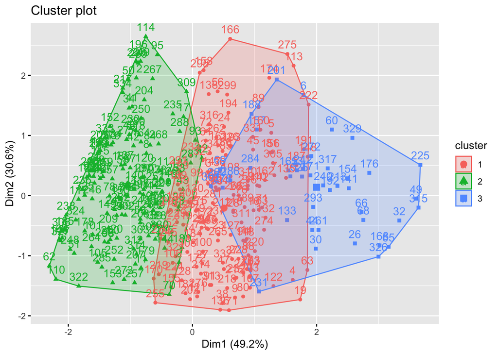

```
##   Model1.cl Model1_step.cl Model2.cl Model2_step.cl
## 1  3811.881       3811.881  8046.807       8077.968
```

# OHIE_Final_Selection.RDS

## Multiple Linear Regression

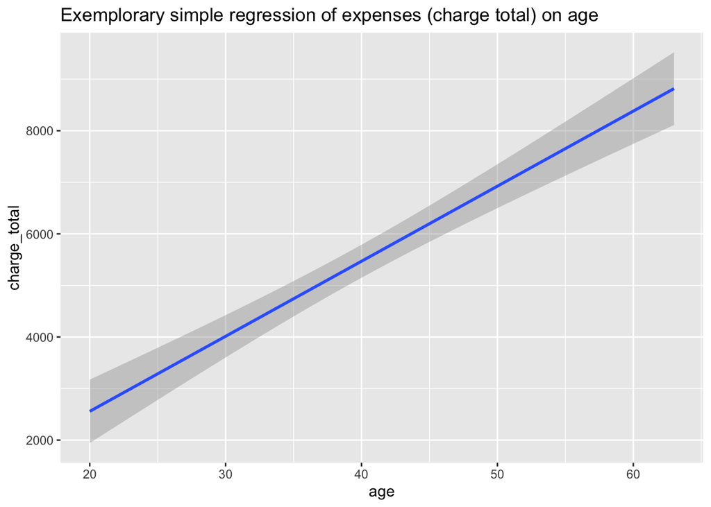

## Support Vector Regression

To incorporate possible non-linear relationships better, a support vectror regression was used to predict expenses. However, primarily due to the problem of overfitting, the initial model performed quite poorly. Whilst optimzuations, such as the stricter feature selection on the basis of AICs resulted in significant improvements to model performance, the overall performance of support vector regressions continued to lag behind both linear and tree based approaches. Support vector based modelling was thus not further explored and optimized. Instead, our team focused on tree based approaches.

## Simple Tree Regression

Single trees can generally be expected to underperform tree based ensembler algorithms such as random forests or gradient boosting. We nevertheless elected to use a simple tree regression as a starting point for our analysis through tree based models, due to its low computation cost and ease of interpretability. This was the resulting regression tree:

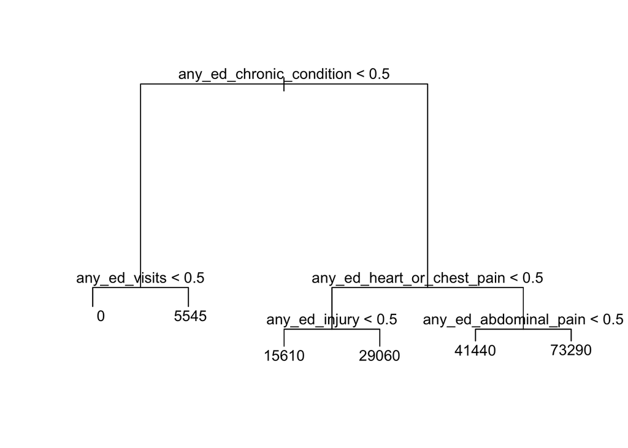

Interestingly, this initial regression tree elected solely criteria from the users medical history as decision factors.

## Random Forest Regression

The single tree performed worse than the optimized linear regression, which appeared to be largely due to problems of overfitting. Through the use of random forests, this performance could be enhanced significantly. The best performing random forest, namely the ranodom forest using the AIC optimized features within the linear gregression model, outperformed the linear regression with ACI optimized features and interaction terms with the variable sex.

## Gradient Boosting Regressing utilizing decision trees

In addition to the single tree and random forests, we implemented gradient boosting, as a third tree based method. Within this method, new trees are constructed using the information of already constructed trees, which differentiates it from random forests where additional tress are constructed independently of the already constructed trees. The problem of overfitting, was even more apparent under this algorithm. The following graph of the in sample and out of sample error rates of the boosting model with the AIC optimized features illustrates the influence of overfitting especially clearly:

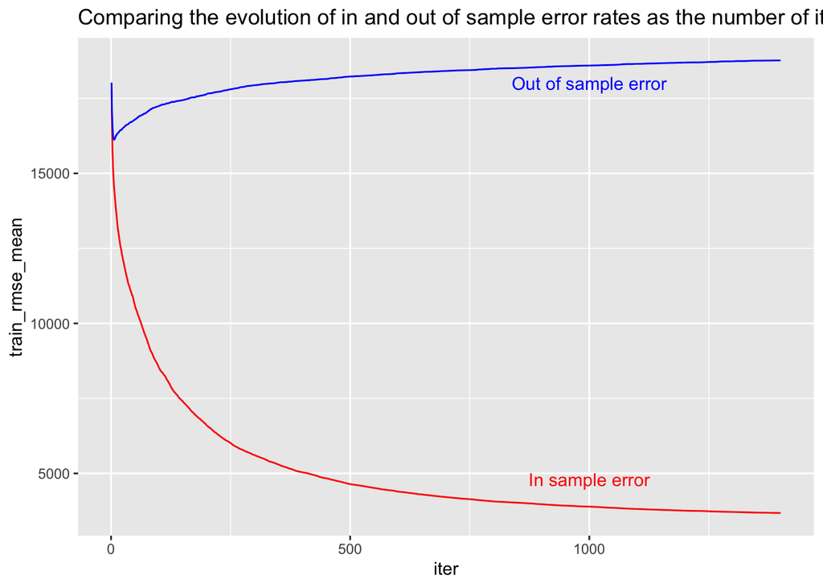

Subsequent of the tweaking of factors such as the number of iterations and the tree depth to avoid overfitting, the gradient boosting model turned out to be the best performing model overall. It it thus the model, which our service utilizes.

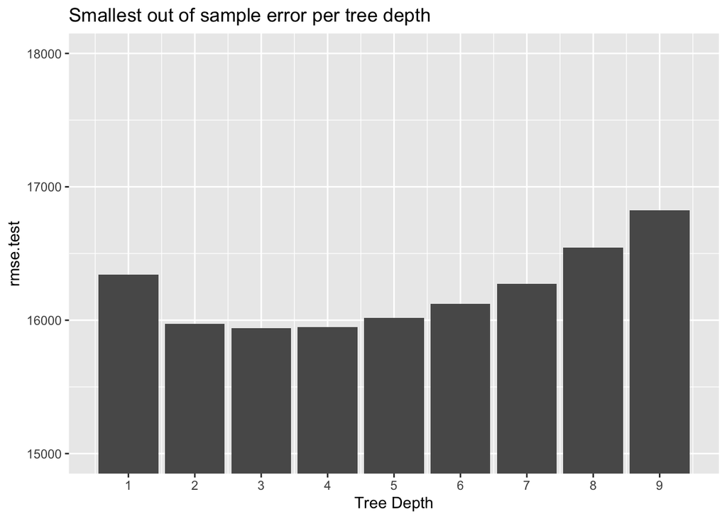

## Artificial Neural Network Regression

because NN haven’t been covered in class we’ll quickly show what a NN looks like. A Neural Network with 1 Hidden Layer and 1 Neuron, using a softplus activation function.

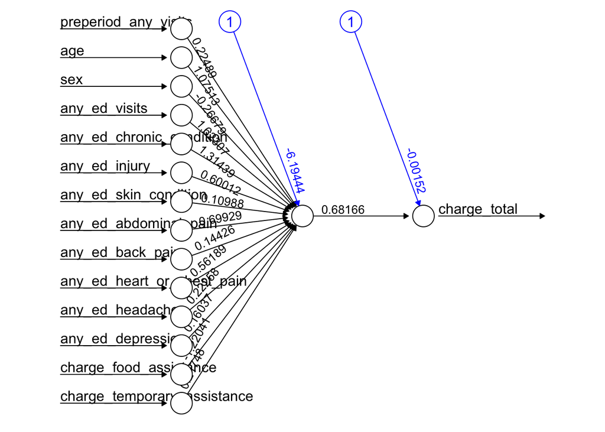

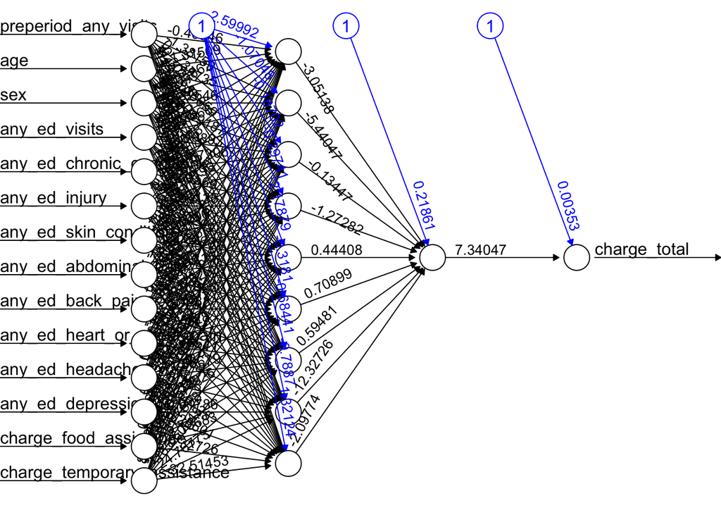

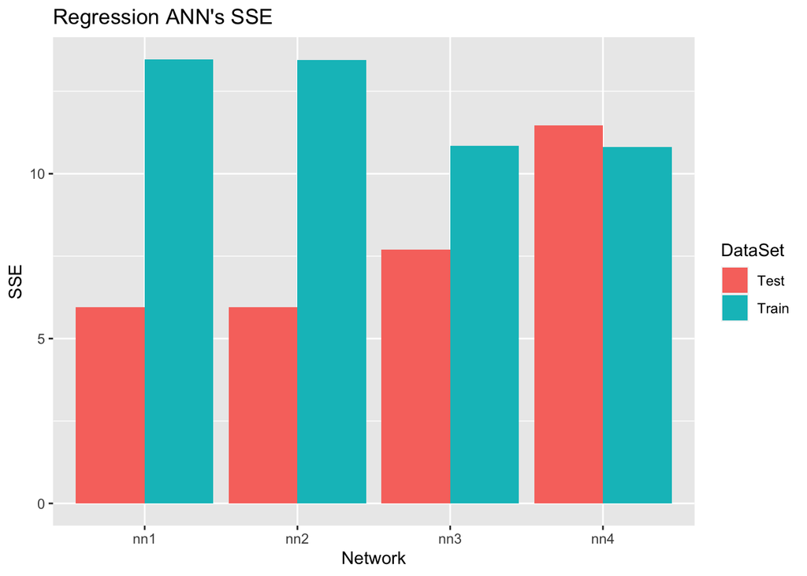